# Tarea de Modelo lineales Parte 1

# Parte 1

### Librerias:

```r
library(dplyr)
library(psych)
library(GGally)
library(knitr)
library(ggplot2)
library(gridExtra)
library(lmtest)
library(corrplot)
library(car)
```

Del siguiente link: https://rpubs.com/Joaquin_AR/226291 ,realice las siguientes acciones:

## a. Replique en un Script de R, los Ejemplos 1 y 2, usando todas las funciones que se presenta el artículo.

### Ejemplo 1:

Para este primer ejemplo se desea generar un modelo que permita predecir la esperanza de vida media de los habitantes de una ciudad en función de diferentes variables. Se dispone de información sobre: habitantes, analfabetismo, ingresos, esperanza de vida, asesinatos, universitarios, heladas, área y densidad poblacional. Los datos se cargan acontinuación:

```r
datos <- as.data.frame(state.x77)
datos <- rename(habitantes = Population, analfabetismo = Illiteracy,
                ingresos = Income, esp_vida = `Life Exp`, asesinatos = Murder,
                universitarios = `HS Grad`, heladas = Frost, area = Area,
                .data = datos)
datos <- mutate(.data = datos, densidad_pobl = habitantes * 1000 / area)
```

#### 1) Analizar la relación entre variables.

Acontinucación, se estudia la relación entre las variables de la base de datos, esto para determinar si existe colinealidad o si se presentan varibales con relaciones de tipo no lineal. Para esto se corre la función `cor()` que devuelve las correlaciones entre variables y se redondea el resultado en el tercer decimal.

```r
as.data.frame(round(cor(x = datos, method = "pearson"), 3))
```

```
##                habitantes ingresos analfabetismo esp_vida asesinatos
## habitantes          1.000    0.208         0.108   -0.068      0.344
## ingresos            0.208    1.000        -0.437    0.340     -0.230
## analfabetismo       0.108   -0.437         1.000   -0.588      0.703
## esp_vida           -0.068    0.340        -0.588    1.000     -0.781
## asesinatos          0.344   -0.230         0.703   -0.781      1.000
## universitarios     -0.098    0.620        -0.657    0.582     -0.488
## heladas            -0.332    0.226        -0.672    0.262     -0.539
## area                0.023    0.363         0.077   -0.107      0.228
## densidad_pobl       0.246    0.330         0.009    0.091     -0.185
##                universitarios heladas   area densidad_pobl
## habitantes             -0.098  -0.332  0.023         0.246
## ingresos                0.620   0.226  0.363         0.330
## analfabetismo          -0.657  -0.672  0.077         0.009
## esp_vida                0.582   0.262 -0.107         0.091
## asesinatos             -0.488  -0.539  0.228        -0.185
## universitarios          1.000   0.367  0.334        -0.088
## heladas                 0.367   1.000  0.059         0.002
## area                    0.334   0.059  1.000        -0.341
## densidad_pobl          -0.088   0.002 -0.341         1.000
```

Además, se representa la distribución de las vaiables mediante histogramas. Esto con ayuda de la fucnción `multi.hist()`.

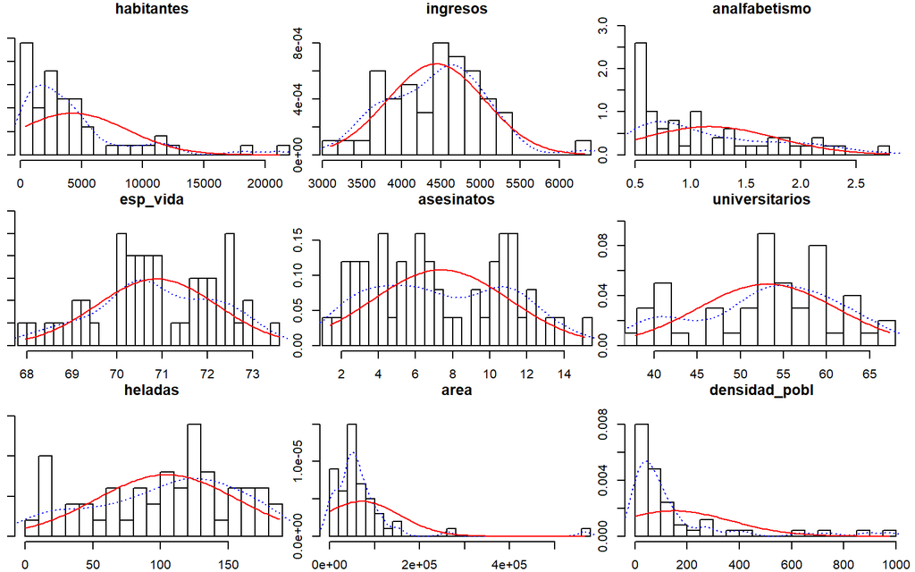

```r
multi.hist(x = datos, dcol = c("blue", "red"), dlty = c("dotted", "solid"), global = F)
```

Otro ejemplo en el que se calculan las correlaciones y se generan histogramas a la vez, se encuentra con la función `ggpairs()`.

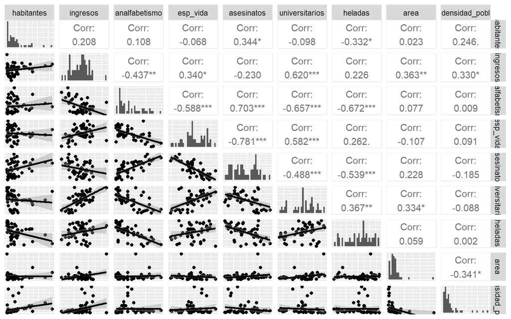

```r
ggpairs(datos, lower = list(continuous = "smooth"),
        diag = list(continuous = "barDiag"), axisLabels = "none")
```

De lo anterior se extra que las variables con mayor relación con `esp_vida` son `asesinatos`, `analfabetismo` y `universitarios`. Además, dado que las primeras dos variables poseen cierto grado de correlación, pude suceder que no sea útil intoducir ambas al modelo.

#### 2) Generar el modelo.

Ahora, que se conoce la información repecto a las correlaciones y posibles distribuciones, se procede a generar un modelo mediante el método mixto y utilizando la medición AIC para la validación de los predictores.

```r
modelo <- lm(esp_vida ~ habitantes + ingresos + analfabetismo + asesinatos +
             universitarios + heladas + area + densidad_pobl, data = datos )

summary(modelo)
```

```
##
## Call:
## lm(formula = esp_vida ~ habitantes + ingresos + analfabetismo +
##     asesinatos + universitarios + heladas + area + densidad_pobl,
##     data = datos)
##
## Residuals:
##      Min       1Q   Median       3Q      Max
## -1.47514 -0.45887 -0.06352  0.59362  1.21823
##
## Coefficients:
##                  Estimate Std. Error t value Pr(>|t|)
## (Intercept)     6.995e+01  1.843e+00  37.956  < 2e-16 ***
## habitantes      6.480e-05  3.001e-05   2.159   0.0367 *
## ingresos        2.701e-04  3.087e-04   0.875   0.3867
## analfabetismo   3.029e-01  4.024e-01   0.753   0.4559
## asesinatos     -3.286e-01  4.941e-02  -6.652 5.12e-08 ***
## universitarios  4.291e-02  2.332e-02   1.840   0.0730 .
## heladas        -4.580e-03  3.189e-03  -1.436   0.1585
## area           -1.558e-06  1.914e-06  -0.814   0.4205
## densidad_pobl  -1.105e-03  7.312e-04  -1.511   0.1385
## ---
## Signif. codes:  0 '***' 0.001 '**' 0.01 '*' 0.05 '.' 0.1 ' ' 1
##
## Residual standard error: 0.7337 on 41 degrees of freedom
## Multiple R-squared:  0.7501, Adjusted R-squared:  0.7013
## F-statistic: 15.38 on 8 and 41 DF,  p-value: 3.787e-10
```

Con lo anterior se obtiene que el modelo pude explicar aproximadamente el 75% de la variabilidad, esto ya que el $R^{2}$ fue de 0.7501. Por otro lado, ya que el p-valor obtenido fue significativo se pude aceptar que no se llegó al modelo por azar. Ademán, al menos uno de los coeficientes parciales de regresión es diferente de cero.

#### 3) Selección de los mejores predictores.

Ahora se procede a seleccionar los mejores predictores empleando el método AIC.

```r
step(object = modelo, direction = "both", trace = 1)
```

```
## Start:  AIC=-22.89
## esp_vida ~ habitantes + ingresos + analfabetismo + asesinatos +
##     universitarios + heladas + area + densidad_pobl
##
##                  Df Sum of Sq    RSS     AIC
## - analfabetismo   1    0.3050 22.373 -24.208
## - area            1    0.3564 22.425 -24.093
## - ingresos        1    0.4120 22.480 -23.969
## <none>                        22.068 -22.894
## - heladas         1    1.1102 23.178 -22.440
## - densidad_pobl   1    1.2288 23.297 -22.185
## - universitarios  1    1.8225 23.891 -20.926
## - habitantes      1    2.5095 24.578 -19.509
## - asesinatos      1   23.8173 45.886  11.707
##
## Step:  AIC=-24.21
## esp_vida ~ habitantes + ingresos + asesinatos + universitarios +
##     heladas + area + densidad_pobl
##
##                  Df Sum of Sq    RSS     AIC
## - area            1    0.1427 22.516 -25.890
## - ingresos        1    0.2316 22.605 -25.693
## <none>                        22.373 -24.208
## - densidad_pobl   1    0.9286 23.302 -24.174
## - universitarios  1    1.5218 23.895 -22.918
## + analfabetismo   1    0.3050 22.068 -22.894
## - habitantes      1    2.2047 24.578 -21.509
## - heladas         1    3.1324 25.506 -19.656
## - asesinatos      1   26.7071 49.080  13.072
##
## Step:  AIC=-25.89
## esp_vida ~ habitantes + ingresos + asesinatos + universitarios +
##     heladas + densidad_pobl
##
##                  Df Sum of Sq    RSS     AIC
## - ingresos        1     0.132 22.648 -27.598
## - densidad_pobl   1     0.786 23.302 -26.174
## <none>                        22.516 -25.890
## - universitarios  1     1.424 23.940 -24.824
## + area            1     0.143 22.373 -24.208
```

[output cut: 18 more lines]

```
## - asesinatos      1    33.626 56.274  15.910
##
## Step:  AIC=-28.16
## esp_vida ~ habitantes + asesinatos + universitarios + heladas
##
##                  Df Sum of Sq    RSS     AIC
## <none>                        23.308 -28.161
## + densidad_pobl   1     0.660 22.648 -27.598
## + ingresos        1     0.006 23.302 -26.174
## + analfabetismo   1     0.004 23.304 -26.170
## + area            1     0.001 23.307 -26.163
## - habitantes      1     2.064 25.372 -25.920
## - heladas         1     3.122 26.430 -23.877
## - universitarios  1     5.112 28.420 -20.246
## - asesinatos      1    34.816 58.124  15.528
```

```
##
## Call:
## lm(formula = esp_vida ~ habitantes + asesinatos + universitarios +
##     heladas, data = datos)
##
## Coefficients:
##    (Intercept)      habitantes      asesinatos  universitarios         heladas
##      7.103e+01       5.014e-05      -3.001e-01       4.658e-02      -5.943e-03
```

Por lo tanto el mejor modelo resulta de tomar `habitantes`, `asesinatos`, `universitarios` y `heladas` como predictores.

```r
modelo <- (lm(formula = esp_vida ~ habitantes + asesinatos + universitarios +
              heladas, data = datos))
summary(modelo)
```

```
##
## Call:
## lm(formula = esp_vida ~ habitantes + asesinatos + universitarios +
##     heladas, data = datos)
##
## Residuals:
##      Min       1Q   Median       3Q      Max
## -1.47095 -0.53464 -0.03701  0.57621  1.50683
##
## Coefficients:
##                  Estimate Std. Error t value Pr(>|t|)
## (Intercept)     7.103e+01  9.529e-01  74.542  < 2e-16 ***
## habitantes      5.014e-05  2.512e-05   1.996  0.05201 .
## asesinatos     -3.001e-01  3.661e-02  -8.199 1.77e-10 ***
## universitarios  4.658e-02  1.483e-02   3.142  0.00297 **
## heladas        -5.943e-03  2.421e-03  -2.455  0.01802 *
## ---
## Signif. codes:  0 '***' 0.001 '**' 0.01 '*' 0.05 '.' 0.1 ' ' 1
##
## Residual standard error: 0.7197 on 45 degrees of freedom
## Multiple R-squared:  0.736,  Adjusted R-squared:  0.7126
## F-statistic: 31.37 on 4 and 45 DF,  p-value: 1.696e-12
```

Se muestra un intervalo de confianza para cada coeficiente parcial de regresión.

```r
confint(lm(formula = esp_vida ~ habitantes + asesinatos + universitarios +
            heladas, data = datos))
```

```
##                        2.5 %        97.5 %
## (Intercept)     6.910798e+01 72.9462729104
## habitantes     -4.543308e-07  0.0001007343
## asesinatos     -3.738840e-01 -0.2264135705
## universitarios  1.671901e-02  0.0764454870
## heladas        -1.081918e-02 -0.0010673977
```

#### 4) Validación de condiciones para la regresión múltiple lineal.

Ahora se valida la condición de variabilidad constante para los residuos es decir la homocesdasticidad.

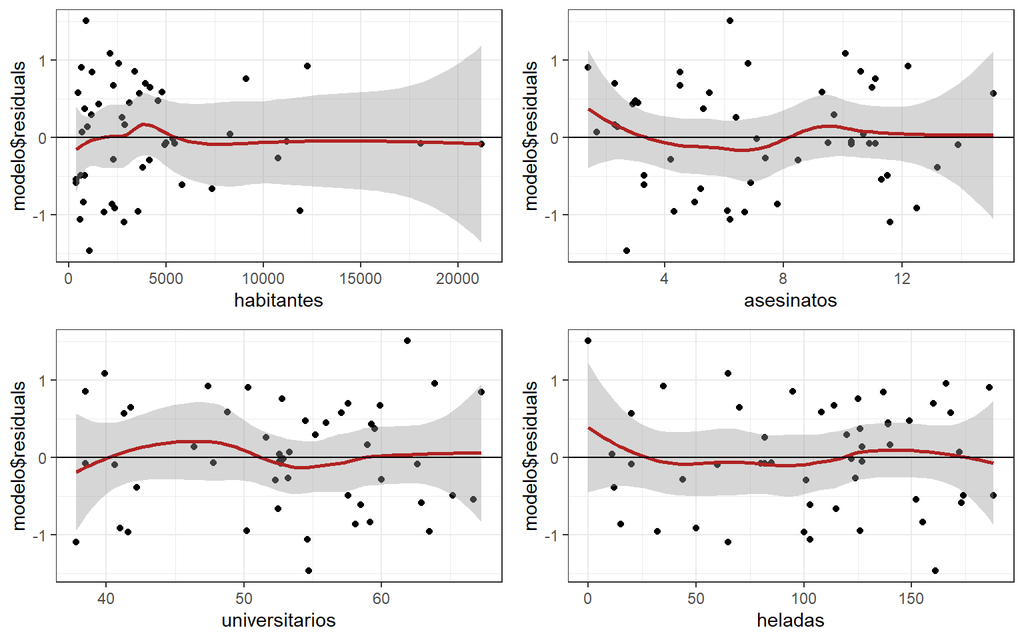

```r
plot1 <- ggplot(data = datos, aes(habitantes, modelo$residuals)) +
    geom_point() + geom_smooth(color = "firebrick") + geom_hline(yintercept = 0) +
    theme_bw()
plot2 <- ggplot(data = datos, aes(asesinatos, modelo$residuals)) +
    geom_point() + geom_smooth(color = "firebrick") + geom_hline(yintercept = 0) +
    theme_bw()
plot3 <- ggplot(data = datos, aes(universitarios, modelo$residuals)) +
    geom_point() + geom_smooth(color = "firebrick") + geom_hline(yintercept = 0) +
    theme_bw()
plot4 <- ggplot(data = datos, aes(heladas, modelo$residuals)) +
    geom_point() + geom_smooth(color = "firebrick") + geom_hline(yintercept = 0) +
    theme_bw()
grid.arrange(plot1, plot2, plot3, plot4)
```

Ahora se testea la distribución normal de los residuos.

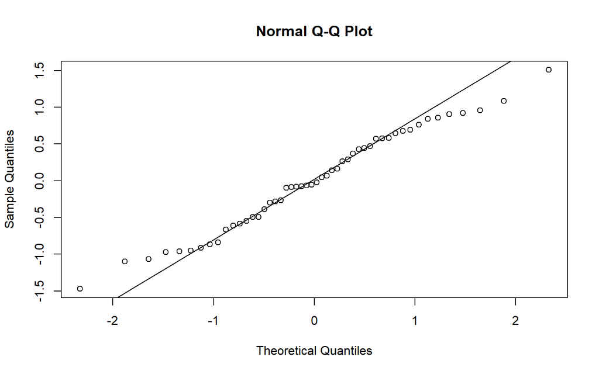

```r
qqnorm(modelo$residuals)
qqline(modelo$residuals)
```

```r
shapiro.test(modelo$residuals)
```

```
##
##  Shapiro-Wilk normality test
##
## data:  modelo$residuals
## W = 0.97935, p-value = 0.525
```

Se concluye que el análisis gráfico y la prueba, confirman la normalidad de los residuos.

Cuando graficamos los residuos en función de los valores ajustados por el modelo, esperamos ver que los residuos se distribuyan aleatoriamente alrededor de cero, sin mostrar ningún patrón. Además, esperamos que la variabilidad de los residuos sea más o menos constante a lo largo del eje X. Sin embargo, si identificamos algún patrón específico en la distribución de los residuos, como una forma cónica o una mayor dispersión en los extremos, esto indica que la variabilidad de los residuos está relacionada con los valores ajustados por el modelo, lo que sugiere una falta de homocedasticidad en el mismo.

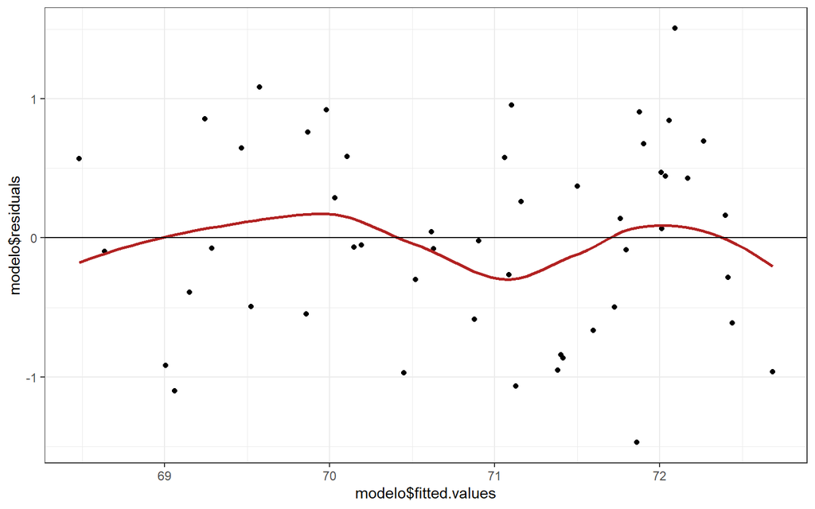

```r
ggplot(data = datos, aes(modelo$fitted.values, modelo$residuals)) +
geom_point() +
geom_smooth(color = "firebrick", se = FALSE) +
geom_hline(yintercept = 0) +
theme_bw()
```

```r
bptest(modelo)
```

```
##
##  studentized Breusch-Pagan test
##
## data:  modelo
## BP = 6.2721, df = 4, p-value = 0.1797
```

Por lo tanto no hay evidencia de ausencia de homocedasticidad.

Relación entre los predictores.

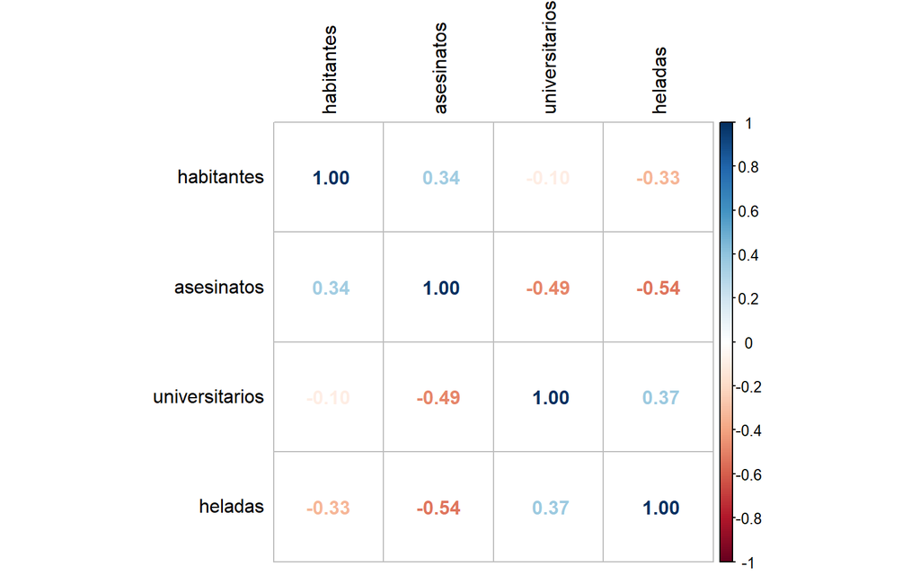

```r
corrplot(cor(dplyr::select(datos, habitantes, asesinatos,universitarios,heladas)),
         method = "number", tl.col = "black")
```

Análisis de Inflación de la Varianza.

```r
vif(modelo)
```

```
##     habitantes     asesinatos universitarios        heladas
##       1.189835       1.727844       1.356791       1.498077
```

El resultado anterior señala que no hay evidencia de una correlación lineal muy alta ni inflación de varianza.

Autocorrelación.

```r
dwt(modelo, alternative = "two.sided")
```

```
##  lag Autocorrelation D-W Statistic p-value
##    1      0.02867262      1.913997   0.788
##  Alternative hypothesis: rho != 0
```

El resultado anterior muestra que no existe evidencia de auto correlación.

#### 5) Identificación de posibles valores atípicos o influyentes.

Identificación de posibles valores atípicos.

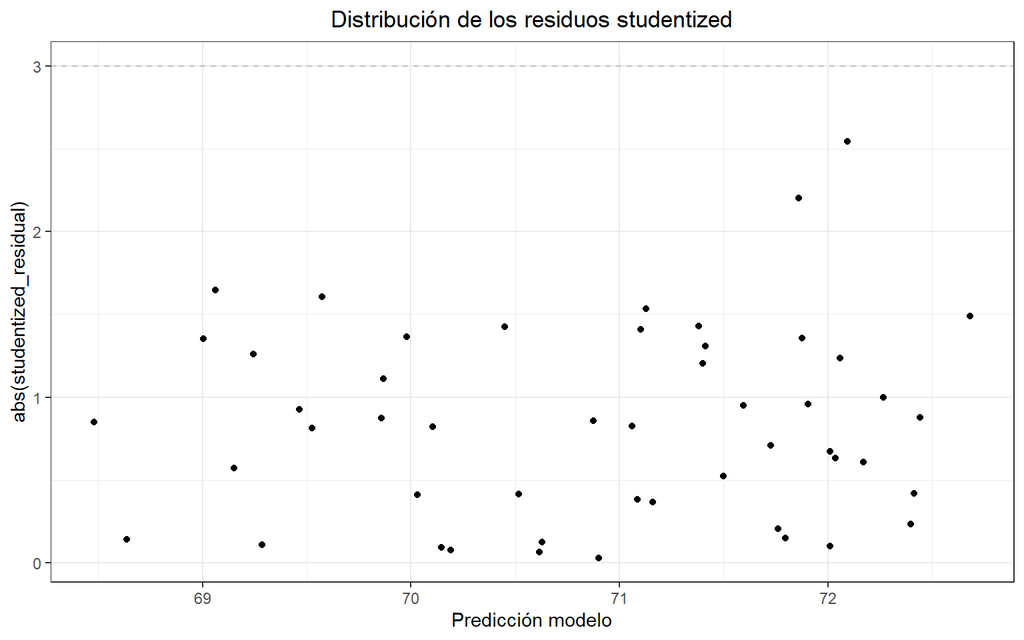

```r
datos$studentized_residual <- rstudent(modelo)

ggplot(data = datos, aes(x = predict(modelo), y = abs(studentized_residual))) +
  geom_hline(yintercept = 3, color = "grey", linetype = "dashed") +

# se identifican en rojo observaciones con residuos estandarizados absolutos > 3
geom_point(aes(color = ifelse(abs(studentized_residual) > 3, 'red', 'black'))) +
  scale_color_identity() +
  labs(title = "Distribución de los residuos studentized",
       x = "Predicción modelo") +
  theme_bw() + theme(plot.title = element_text(hjust = 0.5))
```

```r
which(abs(datos$studentized_residual) > 3)
```

```
## integer(0)
```

No se encuentran valores atípicos.

```r
summary(influence.measures(modelo))
```

```
## Potentially influential observations of
##   lm(formula = esp_vida ~ habitantes + asesinatos + universitarios +      heladas, data = datos) :
##
##            dfb.1_ dfb.hbtn dfb.assn dfb.unvr dfb.hlds dffit   cov.r   cook.d
## Alaska      0.41   0.18    -0.40    -0.35    -0.16    -0.50    1.36_*  0.05
## California  0.04  -0.09     0.00    -0.04     0.03    -0.12    1.81_*  0.00
## Hawaii     -0.03  -0.57    -0.28     0.66    -1.24_*   1.43_*  0.74    0.36
## Nevada      0.40   0.14    -0.42    -0.29    -0.28    -0.52    1.46_*  0.05
## New York    0.01  -0.06     0.00     0.00    -0.01    -0.07    1.44_*  0.00
##            hat
## Alaska      0.25
## California  0.38_*
## Hawaii      0.24
## Nevada      0.29
## New York    0.23
```

En la tabla anterior se listan las observaciones que son significativamente influyentes en al menos uno de los predictores.

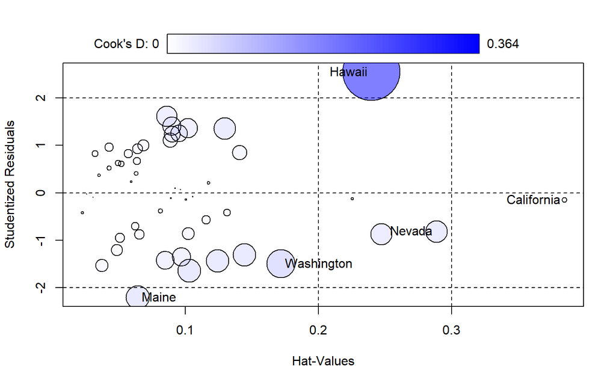

```
##               StudRes        Hat       CookD
## California -0.1500614 0.38475924 0.002879053
## Hawaii      2.5430162 0.23979244 0.363778638
## Maine      -2.2012995 0.06424817 0.061301962
## Nevada     -0.8120831 0.28860921 0.053917754
## Washington -1.4895722 0.17168830 0.089555784
```

```r
influencePlot(modelo)
```

### Ejemplo 2

```r
datos <- data.frame(peso = c(800, 950, 1050, 350, 750, 600, 1075, 250, 700,
                             650, 975, 350, 950, 425, 725),
                    volumen = c(885, 1016, 1125, 239, 701, 641, 1228, 412, 953,
                                929, 1492, 419, 1010, 595, 1034),
                    tipo_tapas = c("duras", "duras", "duras", "duras", "duras",
                                   "duras", "duras", "blandas", "blandas",
                                   "blandas", "blandas", "blandas", "blandas",
                                   "blandas", "blandas"))
head(datos, 4)
```

```
##   peso volumen tipo_tapas
## 1  800     885      duras
## 2  950    1016      duras
## 3 1050    1125      duras
## 4  350     239      duras
```

#### 1) Primero se analiza las correlaciones entre la variable cualitativas.

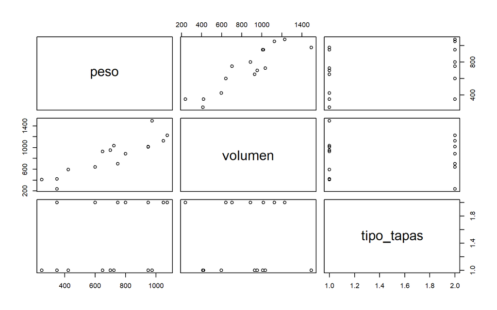

```r
datos$tipo_tapas <- as.factor(datos$tipo_tapas)
pairs(x = datos)
```

```r
cor.test(datos$peso, datos$volumen, method = "pearson")
```

```
##
##  Pearson's product-moment correlation
##
## data:  datos$peso and datos$volumen
## t = 7.271, df = 13, p-value = 6.262e-06
## alternative hypothesis: true correlation is not equal to 0
## 95 percent confidence interval:
##  0.7090393 0.9651979
## sample estimates:
##       cor
## 0.8958988
```

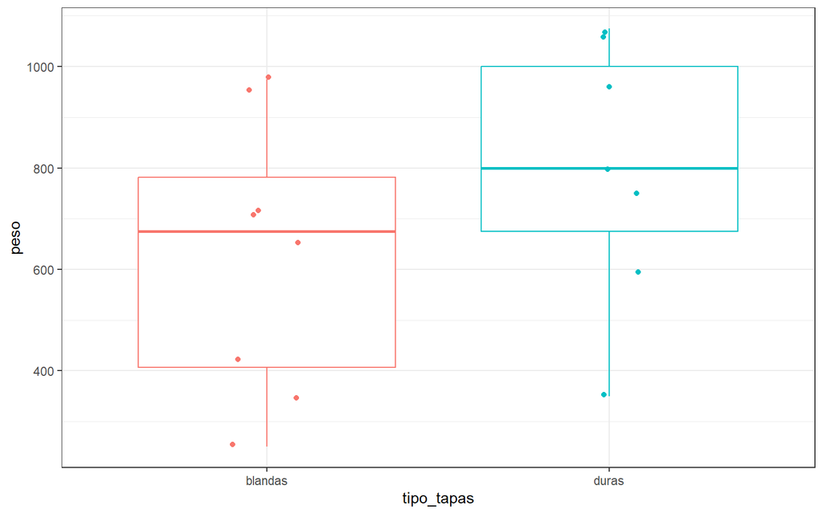

```r
ggplot(data = datos, mapping=aes(x = tipo_tapas, y = peso, color=tipo_tapas)) +
geom_boxplot() +
geom_jitter(width = 0.1) +
theme_bw() + theme(legend.position = "none")
```

Con los análisis anteriores se muestra que existe una relación lineal entre la variable `peso` y `volumen`. Además la variable `tipo_tapas` aparenta influir en el peso.

#### 2) Modelo lineal multiple.

```r
modelo <- lm(peso ~ volumen + tipo_tapas, data = datos)
summary(modelo)
```

```
##
## Call:
## lm(formula = peso ~ volumen + tipo_tapas, data = datos)
##
## Residuals:
##     Min      1Q  Median      3Q     Max
## -110.10  -32.32  -16.10   28.93  210.95
##
## Coefficients:
##                  Estimate Std. Error t value Pr(>|t|)
## (Intercept)      13.91557   59.45408   0.234 0.818887
## volumen           0.71795    0.06153  11.669  6.6e-08 ***
## tipo_tapasduras 184.04727   40.49420   4.545 0.000672 ***
## ---
## Signif. codes:  0 '***' 0.001 '**' 0.01 '*' 0.05 '.' 0.1 ' ' 1
##
## Residual standard error: 78.2 on 12 degrees of freedom
## Multiple R-squared:  0.9275, Adjusted R-squared:  0.9154
## F-statistic: 76.73 on 2 and 12 DF,  p-value: 1.455e-07
```

```r
confint(modelo)
```

```
##                        2.5 %      97.5 %
## (Intercept)     -115.6237330 143.4548774
## volumen            0.5839023   0.8520052
## tipo_tapasduras   95.8179902 272.2765525
```

Por lo anterior, el modelo es capaz de explicar aproximadamente el 92.7% de la variabilidad observada, en el peso. Además, por el F teste, se puede decir que la muestra fue significativa.

#### 3) Elección de los predictores.

En este caso solo hay dos posibles predicotres que mediante la función `summary()` se constataron como importantes.

#### 4) Condiciones para la regresión lineal múltiple.

Relación lineal entre los predictores numéricos y la variable dependiente:

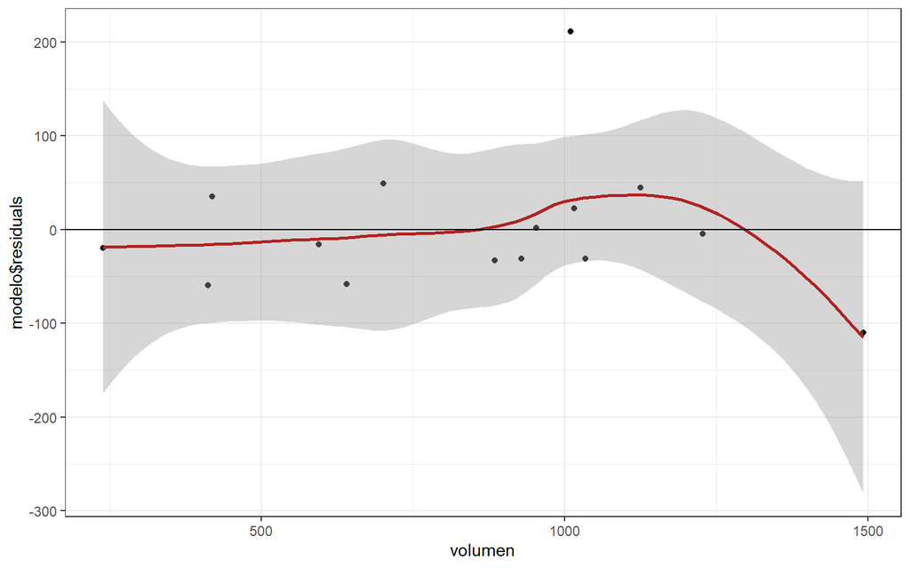

```r
library(ggplot2)
ggplot(data = datos, aes(x = volumen, y = modelo$residuals)) +
geom_point() +
geom_smooth(color = "firebrick") +
geom_hline(yintercept = 0) +
theme_bw()
```

Se satisface la condición de linealidad y se observa un dato que podría ser atípico.

Distribución normal de los residuos:

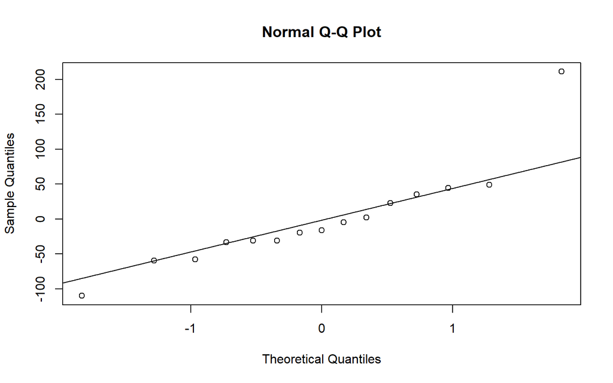

```r
qqnorm(modelo$residuals)
qqline(modelo$residuals)
```

```r
shapiro.test(modelo$residuals)
```

```
##
##  Shapiro-Wilk normality test
##
## data:  modelo$residuals
## W = 0.85497, p-value = 0.02043
```

Por lo anterior, se concluye que la condición de normalidad no se cumple, posiblemente por el dato atípico observado anteriormente. Por lo tanto, se vuelve a correr el código sin el valor atípico.

```r
dato_at <- which.max(modelo$residuals)
shapiro.test(modelo$residuals[-dato_at])
```

```
##
##  Shapiro-Wilk normality test
##
## data:  modelo$residuals[-dato_at]
## W = 0.9602, p-value = 0.7263
```

Por lo tanto, los residuos sí se distribuyen de forma normal.

Variabilidad constante de los residuos:

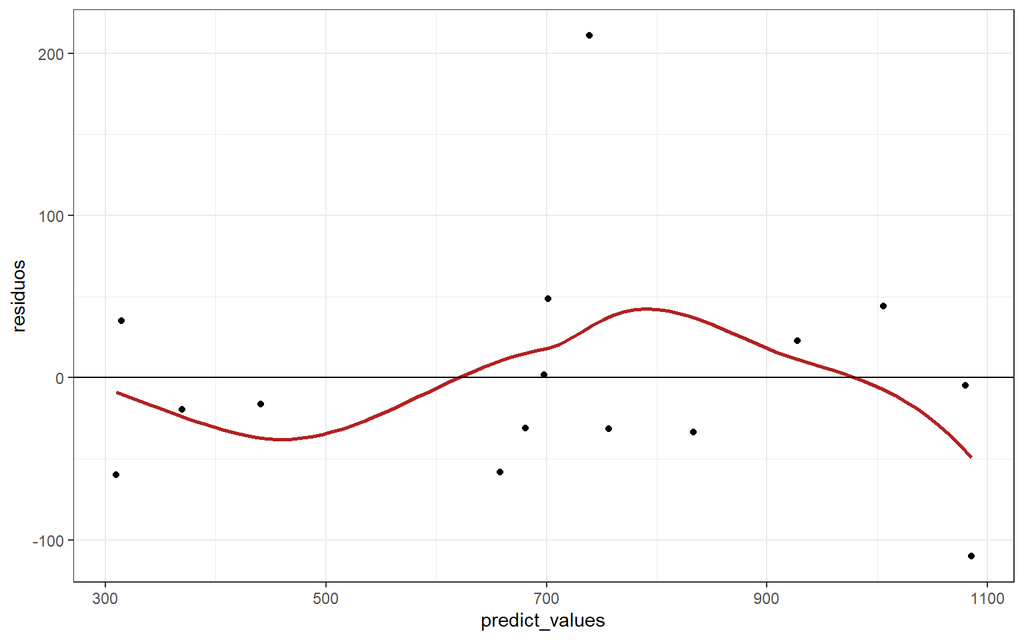

```r
ggplot(data = data.frame(predict_values = predict(modelo),
                         residuos = residuals(modelo)),
       aes(x = predict_values, y = residuos)) +
    geom_point() +
    geom_smooth(color = "firebrick", se = FALSE) +
    geom_hline(yintercept = 0) +
    theme_bw()
```

```r
bptest(modelo)
```

```
##
##  studentized Breusch-Pagan test
##
## data:  modelo
## BP = 2.0962, df = 2, p-value = 0.3506
```

No hay evidencias de falta de homocedasticidad. Además, dado que solo hay un predictor cuantitativo, no se puede dar colinealidad.

Autocorrelación:

```r
dwt(modelo,alternative = "two.sided")
```

```
##  lag Autocorrelation D-W Statistic p-value
##    1    0.0004221711      1.970663   0.812
##  Alternative hypothesis: rho != 0
```

No hay evidencias de autocorrelación.

#### 5) Identificación de posibles valores atípicos o influyentes

```r
outlierTest(modelo)
```

```
##    rstudent unadjusted p-value Bonferroni p
## 13 5.126833         0.00032993     0.004949
```

Justo como se vio anteriormente, existe un dato atípico.

```r
summary(influence.measures(modelo))
```

```
## Potentially influential observations of
##   lm(formula = peso ~ volumen + tipo_tapas, data = datos) :
##
##    dfb.1_ dfb.vlmn dfb.tp_t dffit   cov.r   cook.d hat
## 4  -0.16   0.18    -0.10    -0.23    1.98_*  0.02   0.36
## 11  0.70  -1.26_*   0.57    -1.54_*  0.83    0.64   0.38
## 13  0.31   0.67    -1.31_*   2.07_*  0.04_*  0.46   0.14
```

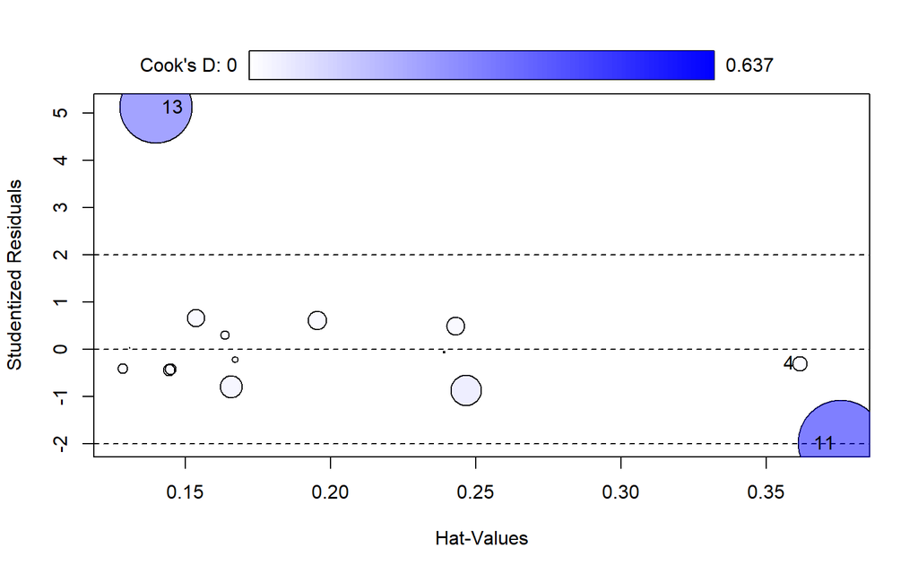

```
##       StudRes       Hat      CookD
## 4  -0.3008849 0.3616894 0.01850173
## 11 -1.9897106 0.3757842 0.63729788
## 13  5.1268330 0.1397761 0.45819722
```

```r
influencePlot(modelo)
```

El análisis anterior muestra la existencia de múltiples observaciones influyentes, pero ninguna preocupante bajo los valores leverage hat o distancia Cook.

#### 6) Conclusión.

El modelo Peso $=13.91557+0.71795$volumen $+184.04727$tipotapas, es capaz de explicar el 92.7% de la variabilidad observada en el pseo de los libros.

## c.Explique los test incluyendo cual es la hipótesis nula.

- Shapiro-Wilk para normalidad: Esta prueba estadística se utiliza para determinar si un conjunto de datos proviene de una distribución normal, para ello se establecen las hipótesis: $H_{0}:$ La distribución es normal y $H_{1}:$ La distribución no es normal. Al realizar la prueba y dado un nivel de significancia, el p-valor arrojado indicará si se rechaza la hipotesis nula ($H_{0}$) o sí, por lo contrario, se acepta.
- Studentized Breusch-Pagan para homocedasticidad: Esta prueba se implementa para corroborar la homocedasticidad al analizar si la varianza estimada de los residuos de una regresión dependen de los valores de las variables independientes. En este test las hipótesis son: $H_{0}:$ Los errores tiene varianza constante y $H_{1}:$ Los errores no tiene varianza constante. Además, como en el test anterior dado un nivel de significancia, el p-valor arrojado podrá o no rechazar la hipótesis nula.